# Boots for Days!

Victoria Zdanowicz

11/11/2021

# Challenge 1

> Using the “KamilarAndCooperData.csv” dataset, run a linear regression looking at log(HomeRange_km2) in relation to log(Body_mass_female_mean) and report your β coeffiecients (slope and intercept).

The assumption of greater uncertainty in our response variable than in our predictor variable may be reasonable in controlled experiments, but for natural observations, measurement of the X variable also typically involves some error and, in fact, in many cases we may not be concered about PREDICTING Y from X but rather want to treat both X and Y as independent variables and explore the relationship between them or consider that both are dependent on some additional parameter, which may be unknown. That is, both are measured rather than “controlled” and both include uncertainty. We thus are not seeking an equation of how Y varies with changes in X, but rather we are look for how they both co-vary in response to some other variable or process. Under these conditions Model II regression analysis may be more appropriate. In Model II approaches, a line of best fit is chosen that minimizes in some way the direct distance of each point to the best fit line. There are several different types of Model II regression, and which to use depends upon the specifics of the case. Common approaches are know as major axis, ranged major axis, and reduced major axis (a.k.a. standard major axis) regression.

**perhaps better to use Model II here since we aren’t seeing if one predicts the other but rather how they co-vary??**

You are definitely taking a much deeper look into the linear model than I did! I did not think of using Model II here, but that is a great idea!

```r
library(dplyr)
library(curl)
```

```r
library(ggplot2)
library(gridExtra)
library(car)
library(lmodel2)
library(sciplot)
```

## Data Preparation

I started by first loading in the Kamilar & Cooper dataset and making 2 distinct objects with the desired variables, omitting NA values.

```r
f <- curl("https://raw.githubusercontent.com/fuzzyatelin/fuzzyatelin.github.io/master/AN588_Fall21/KamilarAndCooperData.csv")
d <- read.csv(f, header = TRUE, sep = ",", stringsAsFactors = FALSE)
head(d)
```

```
##               Scientific_Name          Family          Genus      Species
## 1 Allenopithecus_nigroviridis Cercopithecidae Allenopithecus nigroviridis
## 2         Allocebus_trichotis Cercopithecidae      Allocebus    trichotis
## 3           Alouatta_belzebul        Atelidae       Alouatta     belzebul
## 4             Alouatta_caraya        Atelidae       Alouatta       caraya
## 5            Alouatta_guariba        Atelidae       Alouatta      guariba
## 6           Alouatta_palliata        Atelidae       Alouatta     palliata
##   Brain_Size_Species_Mean Brain_Size_Female_Mean   Brain_size_Ref
## 1                   58.02                  53.70 Isler et al 2008
## 2                      NA                     NA
## 3                   52.84                  51.19 Isler et al 2008
## 4                   52.63                  47.80 Isler et al 2008
## 5                   51.70                  49.08 Isler et al 2008
## 6                   49.88                  48.04 Isler et al 2008
##   Body_mass_male_mean Body_mass_female_mean Mass_Dimorphism
```

[output cut: 62 more lines]

I did not think to omit NA values, but does the model already do this?

```r
d <- select(d,Body_mass_female_mean,HomeRange_km2)
d <- na.omit(d) #I used na.omit after selecting just the desired variables because when I used na.omit on the entire dataset it removed any entry that had an NA in any column, reducing the sample size to 26...
x <- log(d$Body_mass_female_mean) #predictor
y <- log(d$HomeRange_km2) #response
```

## Beta Values

I then determined the beta values using the equations from Module 11 and my code from HW4. These equations determine the regression slope(beta1) and intercept(beta0)

```r
beta1 <- cor(y, x) * sd(y)/sd(x)
beta0 <- mean(y) - beta1 * mean(x)

beta.values <- list(Slope = as.numeric(beta1), Intercept = as.numeric(beta0))
```

As outlined above..

Slope = beta1 = cor(y, x) * sd(y)/sd(x)

Intercept = beta0 = mean(y) - beta1 * mean(x)

```r
beta.values
```

```
## $Slope
## [1] 1.036432
##
## $Intercept
## [1] -9.441231
```

*By using log transformed data, we can assess the percentage of difference between two variables without different units (grams and km) confounding our analysis.*

I also got the same coefficients but just by looking at the summary of the linear model. It is great to do this way though so you really understand the underpinnings of the calculations!

## Linear Regression

You can also determine regression slop and intercept using lm() function, which is much faster/cleaner…

```r
m <- lm(y ~ x, data = d)
summary(m)
```

```
##
## Call:
## lm(formula = y ~ x, data = d)
##
## Residuals:
##     Min      1Q  Median      3Q     Max
## -3.3929 -0.9433 -0.0126  1.0944  3.6826
##
## Coefficients:
##             Estimate Std. Error t value Pr(>|t|)
## (Intercept) -9.44123    0.67293  -14.03   <2e-16 ***
## x            1.03643    0.08488   12.21   <2e-16 ***
## ---
## Signif. codes:  0 '***' 0.001 '**' 0.01 '*' 0.05 '.' 0.1 ' ' 1
##
## Residual standard error: 1.423 on 135 degrees of freedom
## Multiple R-squared:  0.5248, Adjusted R-squared:  0.5213
## F-statistic: 149.1 on 1 and 135 DF,  p-value: < 2.2e-16
```

With summary(m), we can see that the pvalue < 0.05 and thus there appears to be a significant relationship between Female Body Mass and Home Range. We can also see in the summary that the intercept and slope values calculated by hand above are equal to the intercept and x(slope) values from lm summary.

## Plotting the Regression

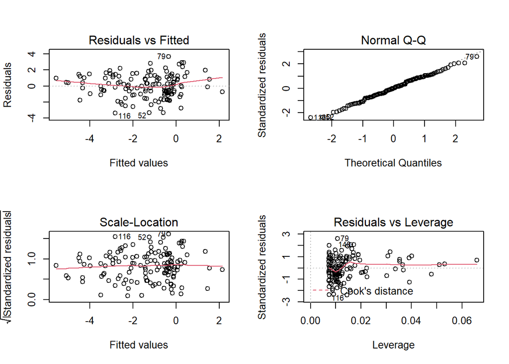

```r
par(mfrow = c(2, 2))
plot(m)
```

The function qqPlot() from the {car} package provides a trend line and confidence intervals that allow us to see exactly which points make the sample fall outside of normality (if any)

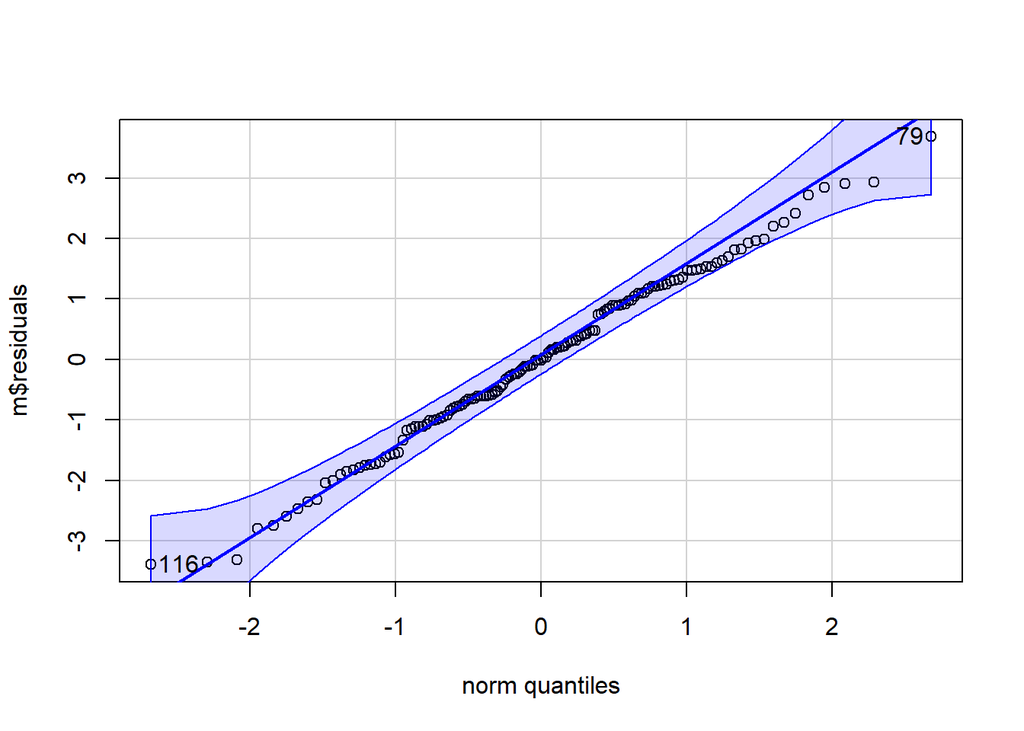

```
##  79 116
##  46  74
```

```r
qqPlot(m$residuals)
```

From these plots, the data appears to be normally distributed. We can also use a Shapiro-Wilk Normality Test, where a low p value would indicate deviation from normality (a measure of how far the trend line of the residuals deviates from the qqplot line).

It is also very impressive that you are using a qqplot and performing a shapiro test, as I only thought to run the model and check the coefficients

```r
s <- shapiro.test(m$residuals)
s
```

```
##
##  Shapiro-Wilk normality test
##
## data:  m$residuals
## W = 0.99387, p-value = 0.8258
```

From this output, the p-value > 0.05 implying that the distribution of the data are not significantly different from normal distribution. Thus, we can assume the normality!

## Model II?

Model II regression may be more appropriate for this analysis since we aren’t testing the predictive relationship between Female mass and Home range, rather how they co-vary?

```r
mII <- lmodel2(y ~ x, data = d, range.y = "interval", range.x = "relative",
    nperm = 1000)
mII
```

```
##
## Model II regression
##
## Call: lmodel2(formula = y ~ x, data = d, range.y = "interval", range.x
## = "relative", nperm = 1000)
##
## n = 137   r = 0.7244503   r-square = 0.5248282
## Parametric P-values:   2-tailed = 1.447292e-23    1-tailed = 7.236458e-24
## Angle between the two OLS regression lines = 17.11835 degrees
##
## Permutation tests of OLS, MA, RMA slopes: 1-tailed, tail corresponding to sign
## A permutation test of r is equivalent to a permutation test of the OLS slope
## P-perm for SMA = NA because the SMA slope cannot be tested
##
## Regression results
##   Method  Intercept    Slope Angle (degrees) P-perm (1-tailed)
## 1    OLS  -9.441231 1.036432        46.02491       0.000999001
## 2     MA -14.032691 1.625245        58.39635       0.000999001
## 3    SMA -12.515243 1.430646        55.04702                NA
## 4    RMA -14.612925 1.699654        59.52936       0.000999001
##
## Confidence intervals
##   Method 2.5%-Intercept 97.5%-Intercept 2.5%-Slope 97.5%-Slope
## 1    OLS      -10.77209       -8.110374  0.8685707    1.204292
## 2     MA      -16.36543      -12.191590  1.3891400    1.924398
## 3    SMA      -13.90072      -11.282822  1.2725988    1.608320
## 4    RMA      -17.08414      -12.708503  1.4554294    2.016565
##
## Eigenvalues: 5.550483 0.7490889
##
## H statistic used for computing C.I. of MA: 0.005225323
```

# Challenge 2

## Bootstrapping

I then used code from HW3 to create a new object with data from sampling dataframe *d* 1000 times *with* replacement. I actually ended up using code from this [link](https://towardsdatascience.com/bootstrap-regression-in-r-98bfe4ff5007)

```r
# Containers for the coefficients
sample_coef_intercept <- NULL
sample_coef_slope <- NULL

for (i in 1:1000) {
  #Creating a resampled dataset from the sample data
  d_boots = d[sample(1:nrow(d), nrow(d), replace = TRUE), ] #WITH replacement

  #Running the regression on these data
  d_boots <- lm(log(HomeRange_km2) ~ log(Body_mass_female_mean), data = d_boots) #I log transformed my y ~ x here

  #Saving the coefficients
  sample_coef_intercept <-
    c(sample_coef_intercept, d_boots$coefficients[1])

  sample_coef_slope <-
    c(sample_coef_slope, d_boots$coefficients[2])
}
```

I believe I used the same website as well.

## Interpreting β coefficients

*Estimate the standard error for each of your β coefficients as the standard deviation of the sampling distribution from your bootstrap and determine the 95% CI for each of your β coefficients based on the appropriate quantiles from your sampling distribution.*

I can use the mean(), sd(), and se() functions with the coefficient objects created above from the entire bootstrap sampling distribution

```r
#Bootstrapped Mean
mean_slope <- mean(sample_coef_slope)
mean_intercept <- mean(sample_coef_intercept)
mean_boots <- list(Slope = as.numeric(mean_slope),Intercept = as.numeric(mean_intercept))

#Bootstrapped Standard Deviation
sd_slope <- sd(sample_coef_slope)
sd_intercept <- sd(sample_coef_intercept)
sd_boots <- list(Slope = as.numeric(sd_slope),Intercept = as.numeric(sd_intercept))

#Bootstrapped Standard Error
se_slope <- se(sample_coef_slope)
se_intercept <- se(sample_coef_intercept)
se_boots <- list(Slope = as.numeric(se_slope),Intercept = as.numeric(se_intercept))

beta.boots <- cbind(mean_boots,sd_boots,se_boots)
beta.boots
```

```
##           mean_boots sd_boots   se_boots
## Slope     1.036591   0.07771258 0.002457488
## Intercept -9.445383  0.6057596  0.0191558
```

I like how cleanly you depicted the data for the mean, standard deviation, and standard error of the slope and intercepts.

I next calculated the 95% confidence intervals for the slope and intercept

```r
#Slope CI
slope.lower <- mean_slope - qnorm(1 - 0.05/2) * se_slope
slope.upper <- mean_slope + qnorm(1 - 0.05/2) * se_slope
ci_slope_boots <- list(Lower = as.numeric(slope.lower), Upper = as.numeric(slope.upper))

#Intercept CI
intercept.lower <- mean_intercept - qnorm(1 - 0.05/2) * se_intercept
intercept.upper <- mean_intercept + qnorm(1 - 0.05/2) * se_intercept
ci_intercept_boots <- list(Lower = as.numeric(intercept.lower), Upper = as.numeric(intercept.upper))

ci_boots <- cbind(ci_slope_boots,ci_intercept_boots)
ci_boots
```

```
##       ci_slope_boots ci_intercept_boots
## Lower 1.031775       -9.482927
## Upper 1.041408       -9.407838
```

Maybe it would read better if you had the slope and intercept as rows and lower and upper bounds as collumns? That way for each row you would have the full confidence interval side by side.

## Comparing Model & Bootstrap

*How does the former compare to the SE estimated from your entire dataset using the formula for standard error implemented in lm()?*

```r
se_model <- coef(summary(m))[, "Std. Error"]
SE_compare <- cbind(se_model,se_boots)
SE_compare
```

```
##             se_model   se_boots
## (Intercept) 0.6729346  0.002457488
## x           0.08487709 0.0191558
```

In the table above we can clearly see that the SE for intercept,β0, and slope,β1, from the bootstrapped dataset (se_boots) is lower than the standard error pulled out of the initial linear regression model (m).

*How does the latter compare to the 95% CI estimated from your entire dataset?*

```r
ci_model <- confint(m, level = 0.90)  #confint() function uses lm object d to calculate confidence intervals.
CI_compare <- cbind(ci_model,ci_boots)
CI_compare
```

```
##             5 %       95 %      ci_slope_boots ci_intercept_boots
## (Intercept) -10.55576 -8.326704 1.031775       -9.482927
## x           0.8958565 1.177007  1.041408       -9.407838
```

I think the best way might be by having the ci for each in a row. I calculated the ci manually however, so I’m not sure how this would be done with confint.

*what is the difference between predict() and confint() ????? predict(m, newdata, interval=“confidence”)*

From what I understand, predict CI is solely for Model II models, whereas confint is for regular lm models. I am not completely sure though!

**This is really good code! I appreciated how thoroughly you investigated each of the models and your usage of qq and shapiro tests. Great work!**